# Comparison of Linear Regression Models on The Canadian Housing Data

Linear Regression allows the prediction of continuous numerical target values based on categorical and numerical features.

In this project, I will:

- Perform data transformation and data cleaning.
- Explore different variations on linear regression on the Canadian Housing Dataset and compare their rmse outcomes.
- Use hyperparameter tuning and cross validation techniques.
- Offer possible explanations to the outcome.
- Provide next steps and improvements.

### Load Libraries

```python
import numpy as np
import pandas as pd

import seaborn as sns
import matplotlib.pyplot as plt
%matplotlib inline
import plotly.express as px


import plotly.graph_objects as go


from sklearn.preprocessing import PolynomialFeatures
from sklearn.linear_model import LinearRegression
from sklearn.preprocessing import OneHotEncoder, LabelEncoder
from sklearn.model_selection import train_test_split
from sklearn.metrics import mean_squared_error

from sklearn.preprocessing import StandardScaler
from sklearn.pipeline import Pipeline


from sklearn.linear_model import RidgeCV
from sklearn.linear_model import LassoCV
from sklearn.linear_model import ElasticNetCV
```

### Functions

To plot the coefficient value of each feature onto a bar graph.

```python
def plot_coef(X,model,name=None):

    plt.figure(figsize=(12,8))
    plt.bar(X.columns[2:],abs(model.coef_[2:]))
    plt.xticks(rotation=90)
    plt.ylabel("$coefficients$")
    plt.title(name)
    plt.show()
    print("R^2 on training  data ",model.score(X_train, y_train))
    print("R^2 on testing data ",model.score(X_test,y_test))
```

Calculate root mean squared error (RMSE)

```python
def rmse(ytrue, ypredicted):
    return np.sqrt(mean_squared_error(ytrue, ypredicted))
```

```python
def  plot_dis(y,yhat):

    plt.figure(figsize=(15,8))
    ax1 = sns.distplot(y, hist=False, color="r", label="Actual Value")
    sns.distplot(yhat, hist=False, color="b", label="Fitted Values" , ax=ax1)
    plt.legend()

    plt.title('Actual vs Fitted Values')
    plt.xlabel('Price (in dollars)')
    plt.ylabel('Proportion of Houses')

    plt.show()
    plt.close()
```

### Loading Data

```python
housing_df = pd.read_csv("cleaned_canada.csv")
housing_df.head()
```

|  | City | Province | Latitude | Longitude | Price | Bedrooms | Bathrooms | Acreage | Property Type | Square Footage | ... | Exterior | Fireplace | Heating | Flooring | Roof | Waterfront | Sewer | Pool | Garden | Balcony |
| --- | --- | --- | --- | --- | --- | --- | --- | --- | --- | --- | --- | --- | --- | --- | --- | --- | --- | --- | --- | --- | --- |
| 0 | Revelstoke | BC | 50.976585 | -118.173149 | 839000.0 | 3.0 | 2.0 | 0.00 | Condo | 891.0 | ... | NaN | No | heat pump | carpet | NaN | No | municipal | No | No | No |
| 1 | Boswell | BC | 49.471870 | -116.770195 | 1150000.0 | 3.0 | 2.0 | 0.32 | Single Family | 1881.0 | ... | NaN | No | heat pump | NaN | NaN | No | septic | No | No | No |
| 2 | West Kelowna | BC | 49.825230 | -119.603253 | 149000.0 | 2.0 | 1.0 | 0.00 | Single Family | 912.0 | ... | Metal | No | NaN | laminate | tar | No | municipal | No | No | No |
| 3 | Kelowna | BC | 49.821860 | -119.480143 | 1298000.0 | 5.0 | 4.0 | 0.69 | Single Family | 4374.0 | ... | NaN | Yes | forced air | NaN | NaN | No | municipal | No | No | No |
| 4 | Maple Ridge | BC | 49.221673 | -122.596637 | 759900.0 | 3.0 | 2.0 | 0.00 | Condo | 1254.0 | ... | NaN | No | radiant | NaN | NaN | No | none | No | No | No |

5 rows × 23 columns

Many categorical and numerical features can already be seen. The Price column will be our target for prediction.

```python
housing_df.info()
```

```
<class 'pandas.core.frame.DataFrame'>
RangeIndex: 44896 entries, 0 to 44895
Data columns (total 23 columns):
 #   Column          Non-Null Count  Dtype
---  ------          --------------  -----
 0   City            44896 non-null  object
 1   Province        44896 non-null  object
 2   Latitude        44896 non-null  float64
 3   Longitude       44896 non-null  float64
 4   Price           44896 non-null  float64
 5   Bedrooms        44896 non-null  float64
 6   Bathrooms       44896 non-null  float64
 7   Acreage         44896 non-null  float64
 8   Property Type   44896 non-null  object
 9   Square Footage  44896 non-null  float64
 10  Garage          44896 non-null  object
 11  Parking         44896 non-null  object
 12  Basement        14962 non-null  object
 13  Exterior        17439 non-null  object
 14  Fireplace       44896 non-null  object
 15  Heating         38242 non-null  object
 16  Flooring        15216 non-null  object
 17  Roof            10052 non-null  object
 18  Waterfront      44896 non-null  object
 19  Sewer           44896 non-null  object
 20  Pool            44896 non-null  object
 21  Garden          44896 non-null  object
 22  Balcony         44896 non-null  object
dtypes: float64(7), object(16)
memory usage: 7.9+ MB
```

We can see from the above output that some features contain a lot of missing values. These must be either handled with a replacement or compelete removal.

```python
housing_df.describe()
```

|  | Latitude | Longitude | Price | Bedrooms | Bathrooms | Acreage | Square Footage |
| --- | --- | --- | --- | --- | --- | --- | --- |
| count | 44896.000000 | 44896.000000 | 4.489600e+04 | 44896.000000 | 44896.000000 | 44896.000000 | 44896.000000 |
| mean | 49.010267 | -106.632760 | 1.070457e+06 | 3.214919 | 2.522652 | 2.485950 | 1787.726323 |
| std | 2.659066 | 22.270395 | 1.442961e+06 | 1.636517 | 1.423765 | 86.626599 | 1988.320406 |
| min | 42.045940 | -135.856018 | 5.000000e+04 | 0.000000 | 0.000000 | 0.000000 | 140.000000 |
| 25% | 48.477511 | -122.887882 | 3.999900e+05 | 2.000000 | 2.000000 | 0.000000 | 975.000000 |
| 50% | 49.217891 | -119.395219 | 6.880000e+05 | 3.000000 | 2.000000 | 0.060000 | 1417.000000 |
| 75% | 49.927914 | -102.485638 | 1.200000e+06 | 4.000000 | 3.000000 | 0.180000 | 2198.000000 |
| max | 65.281488 | -52.668600 | 5.880000e+07 | 37.000000 | 26.000000 | 8600.000000 | 290034.000000 |

We do not care about Latitude and Longitude in the above outcome since they are only positional features

#### Handling Missing Values

Let's visualize each column and the number of missing values they contain

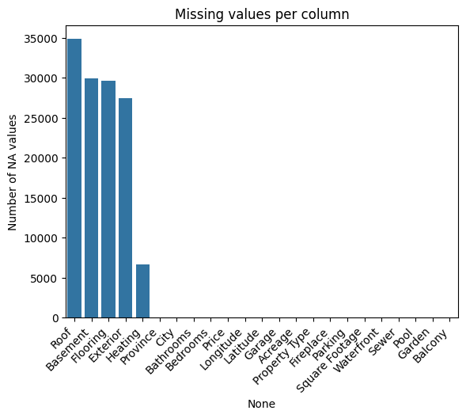

```python
(housing_df.isna().sum().sort_values(ascending=False).pipe(lambda s: sns.barplot(x=s.index, y=s.values)))
plt.xticks(rotation=45, ha='right')
plt.ylabel("Number of NA values")
plt.title("Missing values per column")
plt.show()
```

```python
housing_df = housing_df.drop(["Roof","Basement","Flooring","Exterior"], axis = 1)
housing_df['Heating'] = housing_df['Heating'].fillna("Unknown")
```

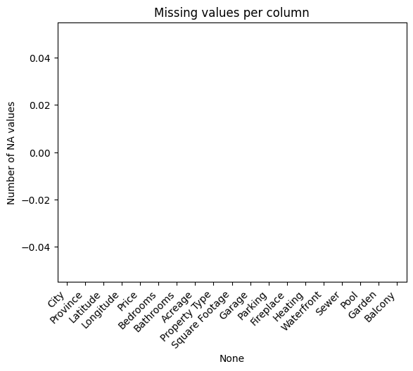

```python
(housing_df.isna().sum().sort_values(ascending=False).pipe(lambda s: sns.barplot(x=s.index, y=s.values)))
plt.xticks(rotation=45, ha='right')
plt.ylabel("Number of NA values")
plt.title("Missing values per column")
plt.show()
```

Looks like there are no more missing values in our dataset. We will print out the info below to double check with numbers.

```python
housing_df.info()
```

```
<class 'pandas.core.frame.DataFrame'>
RangeIndex: 44896 entries, 0 to 44895
Data columns (total 19 columns):
 #   Column          Non-Null Count  Dtype
---  ------          --------------  -----
 0   City            44896 non-null  object
 1   Province        44896 non-null  object
 2   Latitude        44896 non-null  float64
 3   Longitude       44896 non-null  float64
 4   Price           44896 non-null  float64
 5   Bedrooms        44896 non-null  float64
 6   Bathrooms       44896 non-null  float64
 7   Acreage         44896 non-null  float64
 8   Property Type   44896 non-null  object
 9   Square Footage  44896 non-null  float64
 10  Garage          44896 non-null  object
 11  Parking         44896 non-null  object
 12  Fireplace       44896 non-null  object
 13  Heating         44896 non-null  object
 14  Waterfront      44896 non-null  object
 15  Sewer           44896 non-null  object
 16  Pool            44896 non-null  object
 17  Garden          44896 non-null  object
 18  Balcony         44896 non-null  object
dtypes: float64(7), object(12)
memory usage: 6.5+ MB
```

We no longer have missing values in our columns.

We will save categorical and numerical values in variables so we can access them easily later on.

```python
mask = housing_df.dtypes == object
categorical_cols = housing_df.columns[mask]
categorical_cols
```

```
Index(['City', 'Province', 'Property Type', 'Garage', 'Parking', 'Fireplace',
       'Heating', 'Waterfront', 'Sewer', 'Pool', 'Garden', 'Balcony'],
      dtype='object')
```

```python
numeric_columns=list(set(housing_df.columns)-set(categorical_cols))
numeric_columns
```

```
['Bedrooms',
 'Price',
 'Longitude',
 'Acreage',
 'Bathrooms',
 'Latitude',
 'Square Footage']
```

### Overview Plots And EDA

```python
fig = px.scatter_map(
    housing_df,
    lat="Latitude", lon="Longitude",
    color="Price",
    color_continuous_scale="Bluered_r",
    range_color=[min(housing_df['Price']), max(housing_df['Price'])],   # focus scale between 500k and 6M
    size_max=6, zoom=3,
    hover_data=["Price", "Square Footage"],    # add city + price to tooltip
    center={"lat":56,"lon":-106},  # roughly Canada center
    height=650
)

fig.update_layout(
    mapbox_style="carto-positron",
    margin=dict(l=0, r=0, t=40, b=0),
    title="Property Prices in Canada"
)
```

```python
fig = px.scatter_map(
    housing_df,
    lat="Latitude", lon="Longitude",
    color="Square Footage",
    color_continuous_scale="Bluered_r",
    range_color=[min(housing_df['Square Footage']), max(housing_df['Square Footage'])],   # focus scale between 500k and 6M
    size_max=6, zoom=3,
    hover_data=["Price", "Square Footage"],    # add city + price to tooltip
    center={"lat":56,"lon":-106},  # roughly Canada center
    height=650
)

fig.update_layout(
    mapbox_style="carto-positron",
    margin=dict(l=0, r=0, t=40, b=0),
    title="Square Footage of Properties in Canada"
)
```

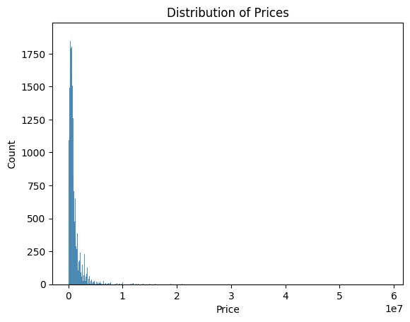

```python
# plt.hist(data = housing_df, x="Price", bins = 100)
sns.histplot(data = housing_df, x = "Price")
plt.title("Distribution of Prices")
plt.xlabel("Price")
plt.ylabel("Count")
```

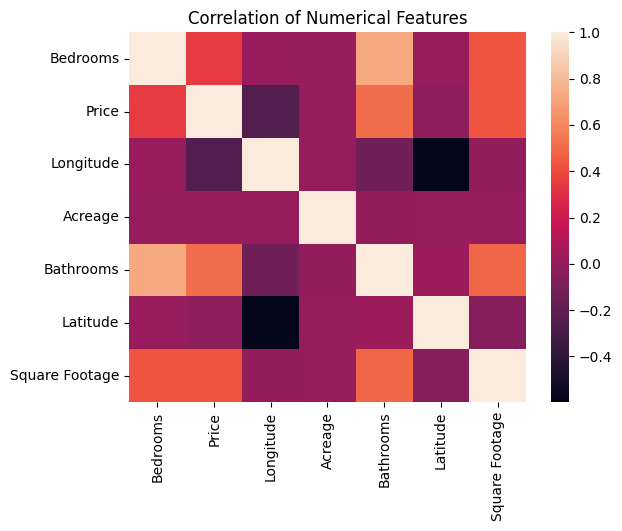

```python
sns.heatmap(housing_df[numeric_columns].corr())
plt.title("Correlation of Numerical Features")
```

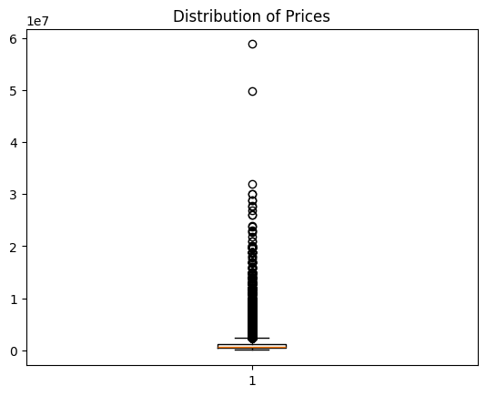

```python
plt.boxplot(housing_df['Price'])
plt.title("Distribution of Prices")
```

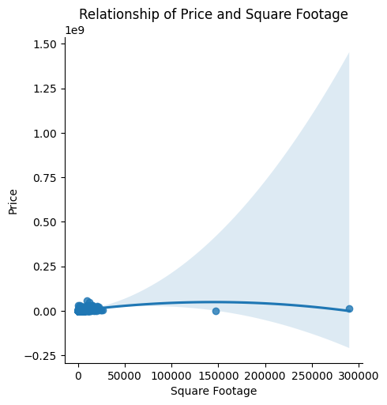

```python
sns.lmplot(x = 'Square Footage', y = 'Price', data = housing_df, order=2)
plt.title("Relationship of Price and Square Footage")
```

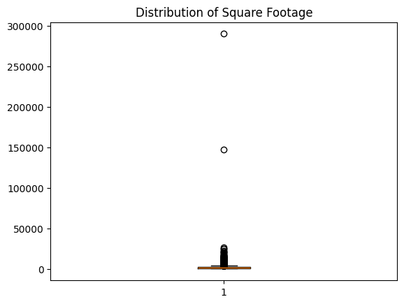

```python
plt.boxplot(housing_df['Square Footage'])
plt.title("Distribution of Square Footage")
```

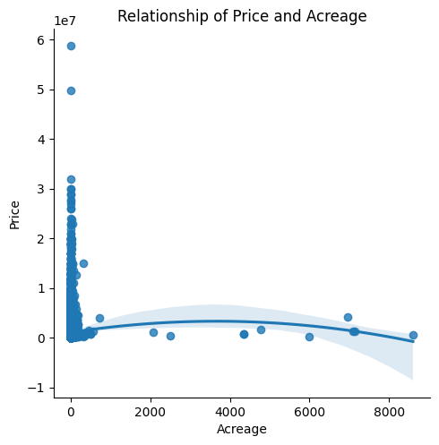

```python
sns.lmplot(x = 'Acreage', y = 'Price', data = housing_df, order=2)
plt.title("Relationship of Price and Acreage")
```

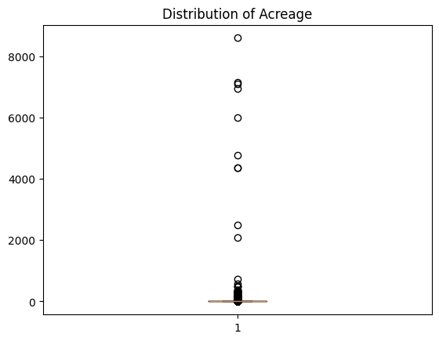

```python
plt.boxplot(housing_df['Acreage'])
plt.title("Distribution of Acreage")
```

Calculating IQR to remove outliers in square footage and acreage features.

```python
Q1 = housing_df['Square Footage'].quantile(0.25)
Q3 = housing_df['Square Footage'].quantile(0.75)
IQR = Q3 - Q1

lower_bound = Q1 - 1.5 * IQR
upper_bound = Q3 + 1.5 * IQR
print(f"Original shape: {housing_df.shape}")

housing_df = housing_df[(housing_df['Square Footage'] >= lower_bound) & (housing_df['Square Footage'] <= upper_bound)]

print(f"New shape: {housing_df.shape}")
```

```
Original shape: (44896, 19)
New shape: (42529, 19)
```

```python
Q1 = housing_df['Acreage'].quantile(0.25)
Q3 = housing_df['Acreage'].quantile(0.75)
IQR = Q3 - Q1

lower_bound = Q1 - 1.5 * IQR
upper_bound = Q3 + 1.5 * IQR
print(f"Original shape: {housing_df.shape}")

housing_df_AcreageOutlierRemoval = housing_df[(housing_df['Acreage'] >= lower_bound) & (housing_df['Acreage'] <= upper_bound)]

print(f"New shape: {housing_df_AcreageOutlierRemoval.shape}")
```

```
Original shape: (42529, 19)
New shape: (37596, 19)
```

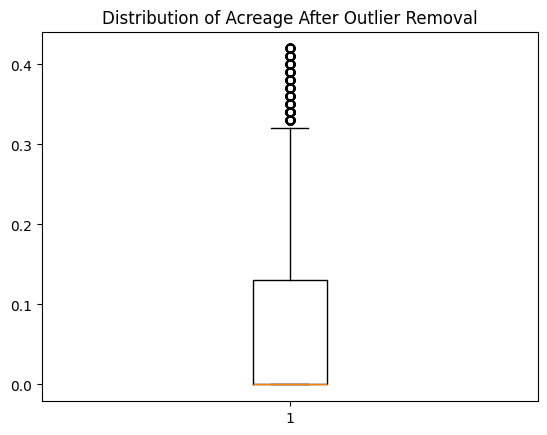

```python
plt.boxplot(housing_df_AcreageOutlierRemoval['Acreage'])
plt.title("Distribution of Acreage After Outlier Removal")
```

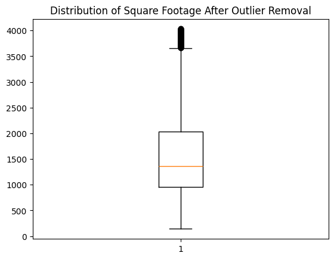

```python
plt.boxplot(housing_df['Square Footage'])
plt.title("Distribution of Square Footage After Outlier Removal")
```

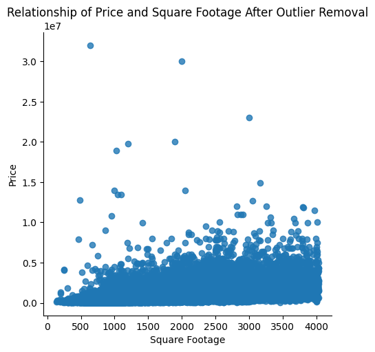

```python
sns.lmplot(x = 'Square Footage', y = 'Price', data = housing_df, order=2)
plt.title("Relationship of Price and Square Footage After Outlier Removal")
```

[figure not shown]

```python
sns.lmplot(x = 'Acreage', y = 'Price', data = housing_df, order=2)
plt.title("Relationship of Price and Acreage After Outlier Removal")
```

#### Handling Categorical Features

```python
for i in categorical_cols:
    print(i)
    print(housing_df[i].unique())
    print('\n')
```

```
City
['Revelstoke' 'Boswell' 'West Kelowna' ... 'Widewater' 'Acme'
 'Drayton Valley']


Province
['BC' 'AB' 'SK' 'ON' 'MB' 'NS' 'PE' 'NB' 'NL' 'NT' 'YT']


Property Type
['Condo' 'Single Family' 'Duplex' 'Townhome' 'Condo/Townhome'
 'MultiFamily' 'Mobile Home' 'Manufactured Home' 'Vacant Land']


Garage
['Yes' 'No']


Parking
['Yes' 'No']


Fireplace
['No' 'Yes']


Heating
['heat pump' 'Unknown' 'radiant' 'forced air' 'boiler' 'no heat'
 'alt heat' 'fireplace' 'space heat' 'other']


Waterfront
['No' 'Yes']


Sewer
['municipal' 'septic' 'none' 'alternative' 'private']


Pool
['No' 'Yes']


Garden
['No' 'Yes']


Balcony
['No' 'Yes']
```

```python
# Determine how many extra columns would be created
num_ohc_cols = (housing_df[categorical_cols]
                .apply(lambda x: x.nunique())
                .sort_values(ascending=False))


# No need to encode if there is only one value
small_num_ohc_cols = num_ohc_cols.loc[num_ohc_cols>1] # filter out the column if it only has 1 unique value

# Number of one-hot columns is one less than the number of categories
small_num_ohc_cols -= 1

small_num_ohc_cols.sum()
```

```
np.int64(3131)
```

```python
num_ohc_cols
```

```
City             3094
Province           11
Heating            10
Property Type       9
Sewer               5
Garage              2
Fireplace           2
Parking             2
Waterfront          2
Pool                2
Garden              2
Balcony             2
dtype: int64
```

```python
small_num_ohc_cols
```

```
City             3093
Province           10
Heating             9
Property Type       8
Sewer               4
Garage              1
Fireplace           1
Parking             1
Waterfront          1
Pool                1
Garden              1
Balcony             1
dtype: int64
```

```python
top_abundant_cities_data = housing_df['City'].value_counts()
top_abundant_cities_data
```

```
City
Vancouver                     3596
Surrey                        3083
Calgary                       2158
Richmond                      1292
Burnaby                       1263
                              ...
Youngstown                       1
Rural Lac Ste. Anne County       1
Nobleford                        1
Consort                          1
Ainsworth                        1
Name: count, Length: 3094, dtype: int64
```

```python
values_to_keep = top_abundant_cities_data[top_abundant_cities_data >= 100].index
values_to_keep
```

```
Index(['Vancouver', 'Surrey', 'Calgary', 'Richmond', 'Burnaby', 'Kelowna',
       'Langley', 'Saskatoon', 'Regina', 'Coquitlam', 'Abbotsford',
       'Chilliwack', 'Hamilton', 'Maple Ridge', 'North Vancouver', 'Delta',
       'New Westminster', 'Nanaimo', 'Kitchener', 'West Kelowna', 'Victoria',
       'Mission', 'Langford', 'West Vancouver', 'Lethbridge', 'Moncton',
       'White Rock', 'Fort McMurray', 'Port Coquitlam', 'Saanich', 'Waterloo',
       'Barrie', 'Swift Current', 'Prince Albert', 'Airdrie', 'Moose Jaw',
       'Burlington', 'Red Deer', 'Halifax', 'St. John's', 'Fort St. John',
       'Medicine Hat', 'Port Moody', 'Charlottetown', 'Grande Prairie',
       'North Battleford', 'Lloydminster', 'Edmonton', 'Cambridge',
       'Chestermere', 'Kamloops', 'Dieppe', 'Windsor', 'Dartmouth', 'Weyburn',
       'Cochrane'],
      dtype='object', name='City')
```

```python
housing_df = housing_df.drop("City", axis = 1)
housing_df.head()
```

|  | Province | Latitude | Longitude | Price | Bedrooms | Bathrooms | Acreage | Property Type | Square Footage | Garage | Parking | Fireplace | Heating | Waterfront | Sewer | Pool | Garden | Balcony |
| --- | --- | --- | --- | --- | --- | --- | --- | --- | --- | --- | --- | --- | --- | --- | --- | --- | --- | --- |
| 0 | BC | 50.976585 | -118.173149 | 839000.0 | 3.0 | 2.0 | 0.00 | Condo | 891.0 | Yes | Yes | No | heat pump | No | municipal | No | No | No |
| 1 | BC | 49.471870 | -116.770195 | 1150000.0 | 3.0 | 2.0 | 0.32 | Single Family | 1881.0 | Yes | Yes | No | heat pump | No | septic | No | No | No |
| 2 | BC | 49.825230 | -119.603253 | 149000.0 | 2.0 | 1.0 | 0.00 | Single Family | 912.0 | No | No | No | Unknown | No | municipal | No | No | No |
| 4 | BC | 49.221673 | -122.596637 | 759900.0 | 3.0 | 2.0 | 0.00 | Condo | 1254.0 | Yes | Yes | No | radiant | No | none | No | No | No |
| 5 | AB | 50.919422 | -113.895609 | 749800.0 | 4.0 | 3.0 | 0.07 | Single Family | 2047.0 | Yes | No | Yes | forced air | No | none | No | Yes | Yes |

```python
# Determine how many extra columns would be created
mask = housing_df.dtypes == object
categorical_cols = housing_df.columns[mask]
categorical_cols

num_ohc_cols = (housing_df[categorical_cols]
                .apply(lambda x: x.nunique())
                .sort_values(ascending=False))


# No need to encode if there is only one value
small_num_ohc_cols = num_ohc_cols.loc[num_ohc_cols>1] # filter out the column if it only has 1 unique value

# Number of one-hot columns is one less than the number of categories
small_num_ohc_cols -= 1

small_num_ohc_cols.sum()
```

```
np.int64(38)
```

```python
small_num_ohc_cols
```

```
Province         10
Heating           9
Property Type     8
Sewer             4
Garage            1
Fireplace         1
Parking           1
Waterfront        1
Pool              1
Garden            1
Balcony           1
dtype: int64
```

```python
# Copy of the data
housing_df_ohc = housing_df.copy()

# The encoders
le = LabelEncoder()
ohc = OneHotEncoder()

for col in num_ohc_cols.index:

    # Integer encode the string categories
    dat = le.fit_transform(housing_df_ohc[col]).astype(int)

    # Remove the original column from the dataframe
    housing_df_ohc = housing_df_ohc.drop(col, axis=1)

    # One hot encode the data--this returns a sparse array
    new_dat = ohc.fit_transform(dat.reshape(-1,1))

    # Create unique column names
    n_cols = new_dat.shape[1]
    col_names = ['_'.join([col, str(x)]) for x in range(n_cols)]

    # Create the new dataframe
    new_df = pd.DataFrame(new_dat.toarray(),
                          index=housing_df_ohc.index,
                          columns=col_names)

    # Append the new data to the dataframe
    housing_df_ohc = pd.concat([housing_df_ohc, new_df], axis=1)
```

```python
housing_df_ohc.head()
```

|  | Latitude | Longitude | Price | Bedrooms | Bathrooms | Acreage | Square Footage | Province_0 | Province_1 | Province_2 | ... | Parking_0 | Parking_1 | Waterfront_0 | Waterfront_1 | Pool_0 | Pool_1 | Garden_0 | Garden_1 | Balcony_0 | Balcony_1 |
| --- | --- | --- | --- | --- | --- | --- | --- | --- | --- | --- | --- | --- | --- | --- | --- | --- | --- | --- | --- | --- | --- |
| 0 | 50.976585 | -118.173149 | 839000.0 | 3.0 | 2.0 | 0.00 | 891.0 | 0.0 | 1.0 | 0.0 | ... | 0.0 | 1.0 | 1.0 | 0.0 | 1.0 | 0.0 | 1.0 | 0.0 | 1.0 | 0.0 |
| 1 | 49.471870 | -116.770195 | 1150000.0 | 3.0 | 2.0 | 0.32 | 1881.0 | 0.0 | 1.0 | 0.0 | ... | 0.0 | 1.0 | 1.0 | 0.0 | 1.0 | 0.0 | 1.0 | 0.0 | 1.0 | 0.0 |
| 2 | 49.825230 | -119.603253 | 149000.0 | 2.0 | 1.0 | 0.00 | 912.0 | 0.0 | 1.0 | 0.0 | ... | 1.0 | 0.0 | 1.0 | 0.0 | 1.0 | 0.0 | 1.0 | 0.0 | 1.0 | 0.0 |
| 4 | 49.221673 | -122.596637 | 759900.0 | 3.0 | 2.0 | 0.00 | 1254.0 | 0.0 | 1.0 | 0.0 | ... | 0.0 | 1.0 | 1.0 | 0.0 | 1.0 | 0.0 | 1.0 | 0.0 | 1.0 | 0.0 |
| 5 | 50.919422 | -113.895609 | 749800.0 | 4.0 | 3.0 | 0.07 | 2047.0 | 1.0 | 0.0 | 0.0 | ... | 1.0 | 0.0 | 1.0 | 0.0 | 1.0 | 0.0 | 0.0 | 1.0 | 0.0 | 1.0 |

5 rows × 56 columns

#### Skewness and Transformation.

Checking for skewness of features is important, as skewed data can lead to biased calculations. Skewed features are then transformed with log1p.

```python
skew_limit = 0.75
skew_vals = housing_df_ohc[numeric_columns].skew()

skew_cols = (skew_vals
             .sort_values(ascending=False)
             .to_frame()
             .rename(columns={0:'Skew'})
             .query('abs(Skew) > {0}'.format(skew_limit)))

skew_cols
```

|  | Skew |
| --- | --- |
| Acreage | 73.826364 |
| Price | 5.628066 |
| Longitude | 1.136677 |
| Square Footage | 0.940756 |
| Bathrooms | 0.839819 |
| Bedrooms | 0.819278 |

These are the skewed features (above 0.75 limit). We will transform them with log1p, including the "Price" target. However, after predictions, we will convert the values back with np.expm1.

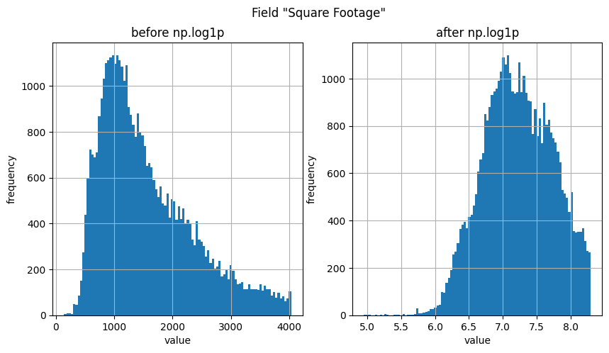

```python
field = "Square Footage"
fig, (ax_before, ax_after) = plt.subplots(1, 2, figsize=(10, 5))
housing_df_ohc[field].hist(ax=ax_before,bins = 100)
housing_df_ohc[field].apply(np.log1p).hist(ax=ax_after,bins = 100)
ax_before.set(title='before np.log1p', ylabel='frequency', xlabel='value')
ax_after.set(title='after np.log1p', ylabel='frequency', xlabel='value')
fig.suptitle('Field "{}"'.format(field));
```

```python
housing_df_ohc_transf = housing_df_ohc.copy()
```

```python
pd.options.mode.chained_assignment = None

for col in skew_cols.index.tolist():
    if col == "Longitude":
        continue
    housing_df_ohc_transf[col] = np.log1p(housing_df_ohc_transf[col])
```

```python
skew_limit = 0.75
skew_vals = housing_df_ohc_transf[numeric_columns].skew()

skew_cols = (skew_vals
             .sort_values(ascending=False)
             .to_frame()
             .rename(columns={0:'Skew'})
             .query('abs(Skew) > {0}'.format(skew_limit)))

skew_cols
```

|  | Skew |
| --- | --- |
| Acreage | 5.163051 |
| Longitude | 1.136677 |

#### Test/Train Split

```python
X = housing_df_ohc_transf.drop(columns=['Price'])
y = housing_df_ohc_transf['Price'].copy()
```

```python
X_train, X_test, y_train, y_test = train_test_split(X,y, test_size=0.3, random_state=42)
```

### Linear Regression Combinations

Standard linear regression, polynomial linear regression, ridge, lasso, and elastic net models are to be trained on the data and their performance in terms of RMSE and R-squared values at train and test phases are to be compared.

#### Standard Linear Regression

```python
steps=[('scaler', StandardScaler()), ('lm',  LinearRegression())]
pipe = Pipeline(steps=steps)
```

```python
pipe.fit(X_train,y_train)
```

```
Pipeline(steps=[('scaler', StandardScaler()), ('lm', LinearRegression())])
```

```python
std_linear_r2_training = pipe.score(X_train, y_train)
std_linear_r2_testing = pipe.score(X_test,y_test)
print("R^2 on training  data ", std_linear_r2_training)
print("R^2 on testing data ", std_linear_r2_testing)
```

```
R^2 on training  data  0.7289436497374611
R^2 on testing data  0.7315770289884782
```

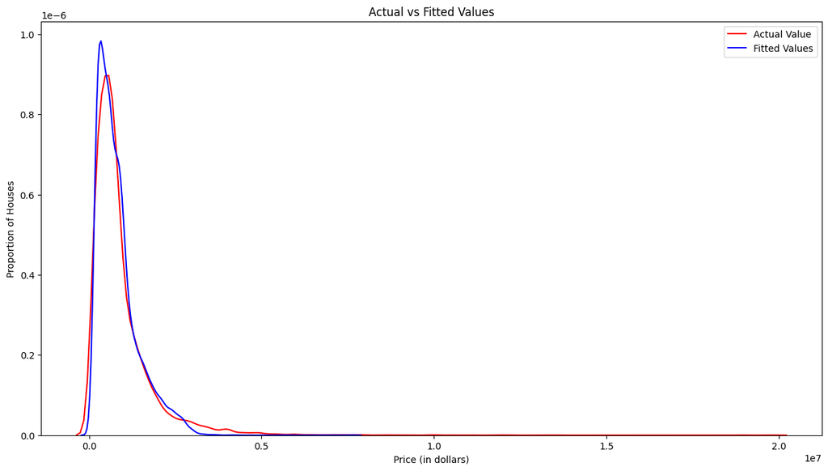

```python
scaled_predictions = pipe.predict(X_test)
scaled_predictions = np.expm1(scaled_predictions)
plot_dis(np.expm1(y_test),scaled_predictions)
```

The model does not capture the actual data as well as expected.

```python
linearRegression_rmse = rmse(np.expm1(y_test),(scaled_predictions))
linearRegression_rmse
```

```
np.float64(642219.9377361297)
```

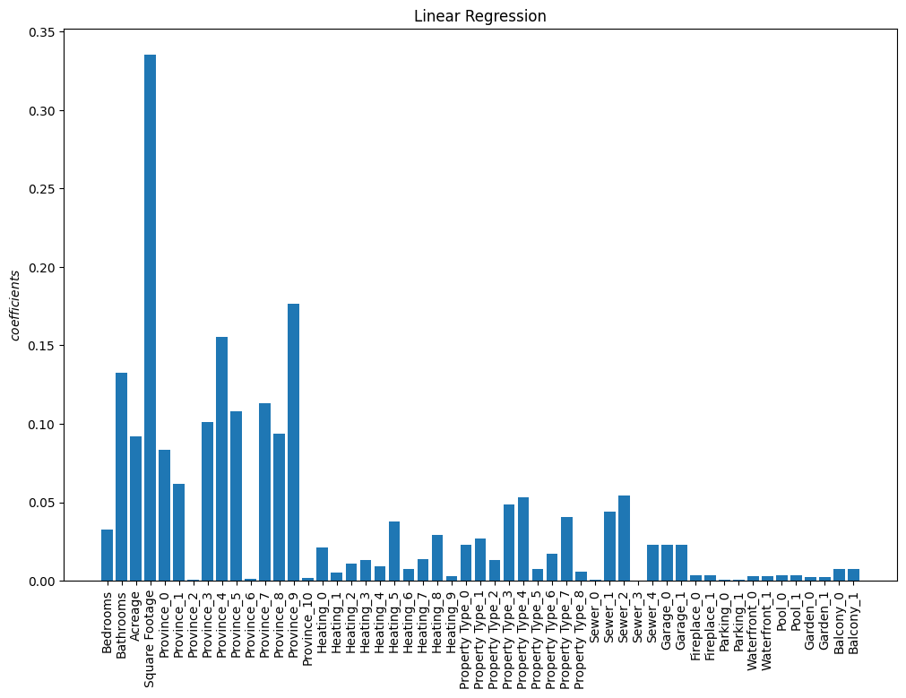

```
R^2 on training  data  -7271.078218329388
R^2 on testing data  -7206.250064629161
```

```python
plot_coef(X,pipe['lm'],name="Linear Regression")
```

Square footage has the largest coefficient. Regularized models should handle these coefficients nicely.

Let's visualize the prediction vs actual values

```
0.43167672662667544
```

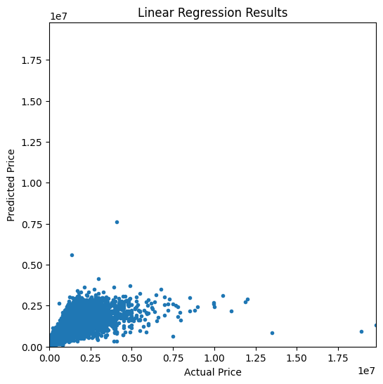

```python
linearRegression = LinearRegression().fit(X_train, y_train)

linearRegression_rmse = rmse(y_test, linearRegression.predict(X_test))

print(linearRegression_rmse)

f = plt.figure(figsize=(6,6))
ax = plt.axes()

ax.plot(np.expm1(y_test), np.expm1(linearRegression.predict(X_test)),
         marker='o', ls='', ms=3.0)

lim = (0, np.expm1(y_test.max()))

ax.set(xlabel='Actual Price',
       ylabel='Predicted Price',
       xlim=lim,
       ylim=lim,
       title='Linear Regression Results');
```

They are almost on a linear line. However, many values stray from the linear relationship.

#### Linear Regression With Polynomial Features

```python
Input=[ ('scaler', StandardScaler()), ('polynomial', PolynomialFeatures(include_bias=False,degree=2)), ('model',LinearRegression())]
```

```python
pipe=Pipeline(Input)
pipe.fit(X_train, y_train)
```

```
Pipeline(steps=[('scaler', StandardScaler()),
                ('polynomial', PolynomialFeatures(include_bias=False)),
                ('model', LinearRegression())])
```

```python
polynomial_r2_training = pipe.score(X_train, y_train)
polynomial_r2_testing = pipe.score(X_test,y_test)
print("R^2 on training  data:", polynomial_r2_training)
print("R^2 on testing data:", polynomial_r2_testing)
```

```
R^2 on training  data: 0.8075588686602597
R^2 on testing data: 0.7969454291496358
```

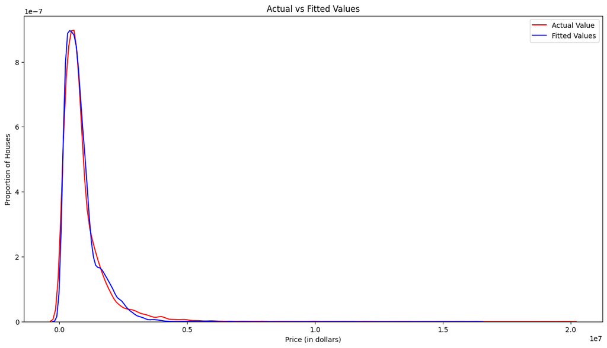

```python
scaled_predictions = pipe.predict(X_test)
scaled_predictions = np.expm1(scaled_predictions)
plot_dis(np.expm1(y_test),scaled_predictions)
```

This relationship is a closer fit than the standard linear regression. Polynomial regression with degree of 2 seems to be more suitable.

```python
Polynomial_rmse = rmse(np.expm1(y_test),(scaled_predictions))
Polynomial_rmse
```

```
np.float64(591917.3157522151)
```

#### Regularization

Ridge, Lasso, and Elastic Net regularization models are tested below. The models will automatically carry out cross validation and hyperparameter tuning.

#### Ridge

```python
alphas=np.logspace(-4, 2, 60)

ridge_pipe = Pipeline([
    ("scale", StandardScaler(with_mean=False)),  # with_mean=False if X is sparse (from OneHotEncoder)
    ("ridge", RidgeCV(alphas=alphas, cv=4))
])

ridge_pipe.fit(X_train, y_train)

predicted_ridgeCV = ridge_pipe.predict(X_test)
predicted_ridgeCV = np.expm1(predicted_ridgeCV)

ridgeCV_rmse = rmse(np.expm1(y_test), predicted_ridgeCV)

print(ridge_pipe['ridge'].alpha_, ridgeCV_rmse)
```

```
0.5790443980602489 642242.3688615687
```

```python
ridge_r2_training = ridge_pipe.score(X_train, y_train)
ridge_r2_testing = ridge_pipe.score(X_test,y_test)
print("R^2 on training  data:", ridge_r2_training)
print("R^2 on testing data:", ridge_r2_testing)
```

```
R^2 on training  data: 0.7289435314112565
R^2 on testing data: 0.7315754458169847
```

#### Lasso

```python
# large max_iter and wide alpha search space to allow convergence
lasso_pipe = Pipeline([
    ("scale", StandardScaler()),
    ("lasso", LassoCV(
        alphas=np.logspace(-4, 2, 60),
        max_iter=200_000,
        cv=5,
        n_jobs=-1,
        tol=1e-3,
        selection="cyclic",
        random_state=42
    ))
])

lasso_pipe.fit(X_train, y_train)
predicted_lassoCV = lasso_pipe.predict(X_test)
predicted_lassoCV = np.expm1(predicted_lassoCV)

lassoCV_rmse = rmse(np.expm1(y_test), predicted_lassoCV)


print("alpha*", lasso_pipe.named_steps["lasso"].alpha_, lassoCV_rmse)
```

```
alpha* 0.0001 642597.5306760235
```

```python
lasso_r2_training = lasso_pipe.score(X_train, y_train)
lasso_r2_testing = lasso_pipe.score(X_test,y_test)
print("R^2 on training  data:", lasso_r2_training)
print("R^2 on testing data:", lasso_r2_testing)
```

```
R^2 on training  data: 0.7289120244360514
R^2 on testing data: 0.7315181792067544
```

#### Elastic Net

```python
enet_pipe = Pipeline([
    ("scale", StandardScaler()),
    ("enet", ElasticNetCV(
        alphas=np.logspace(-4, 2, 60),
        l1_ratio=[0.1, 0.3, 0.5, 0.7, 0.9, 1.0],
        cv=5,
        max_iter=300_000,    # more iterations
        tol=1e-3,            # slightly looser tolerance aids convergence
        n_jobs=-1,
        random_state=42
    ))
])


enet_pipe.fit(X_train, y_train)
predicted_enetCV = enet_pipe.predict(X_test)
predicted_enetCV = np.expm1(predicted_enetCV)

enetCV_rmse = rmse(np.expm1(y_test), predicted_enetCV)


print("alpha*", enet_pipe.named_steps["enet"].alpha_, enetCV_rmse)
```

```
alpha* 0.0001 642358.0949086756
```

```python
enet_r2_training = enet_pipe.score(X_train, y_train)
enet_r2_testing = enet_pipe.score(X_test,y_test)
print("R^2 on training  data:", enet_r2_training)
print("R^2 on testing data:", enet_r2_testing)
```

```
R^2 on training  data: 0.728939356100128
R^2 on testing data: 0.731563800527369
```

```python
rmse_vals = [linearRegression_rmse,Polynomial_rmse,ridgeCV_rmse, lassoCV_rmse, enetCV_rmse]
r2_training_vals = [std_linear_r2_training, polynomial_r2_training, ridge_r2_training, lasso_r2_training, enet_r2_training]
r2_testing_vals = [std_linear_r2_testing, polynomial_r2_testing, ridge_r2_testing, lasso_r2_testing, enet_r2_testing]

labels = ['Standard LR','Polynomial LR','Ridge', 'Lasso', 'ElasticNet']

rmse_df = pd.DataFrame({
    "RMSE": rmse_vals,
    "R2_Train": r2_training_vals,
    "R2_Test": r2_testing_vals
}, index = labels)

print(rmse_df)
```

```
                        RMSE  R2_Train   R2_Test
Standard LR         0.431677  0.728944  0.731577
Polynomial LR  591917.315752  0.807559  0.796945
Ridge          642242.368862  0.728944  0.731575
Lasso          642597.530676  0.728912  0.731518
ElasticNet     642358.094909  0.728939  0.731564
```

#### Conclusion

The Canadian Housing Dataset was imported, cleaned of missing values, transformed to handle skewness, and underwent the linear regression workflows of scaling, adding polynomial features, and regularization.

#### Next Step

The "City" feature was removed from this dataset. However, whether a house is in an urban environment or a rural one has major influence on the price. Additionally, some cities like Vancouver, are known for being more expensive than the rest. In another workflow, the city feature can be kept but simplified to a binary urban/rural. Or, major city names can be kept and the rest can be turned to "other".

Other models should be trained with this data and compared with the linear models. Perhaps a multiple linear regression model could also be a useful test.

Copyright @ IBM Corporation. All rights reserved.